# Connections between Food Prices, Population Nourishment, and Poverty

Brook Chen, Mo Tilmo, Emma Schnee, Madeline Kramer

2/27/2020

## Introduction

This project aims to look generally at global data about Food Prices and Population Nourishment to further understand which areas are most impacted by undernourishment and when. Data and surveillance of these issues have great implications for how to proceed in dealing with a public health issue such as global food insecurity. The source of our data comes from two datasets. The first dataset is a global food price tracker that was collected and compiled by the World Food Program. Their data focuses on providing information on food prices form developing countries. The second dataset that we are pulling from is data from the UN Sustainable Development Goals and the data provides the number of undernourished people per country overtime. This project combines country data that overlaps between the two datasets to create a fuller picture of global food insecurity.

## Summary Information

Undernourishment is a global issue. There are many contributing factors to undernourishment, one of which being global food prices. Our data looks at undernourishment percentages across different countries between 2000 and 2017. Between these years the highest prevelance of undernourished people was 71.5 percent in Angola. There were multiple countries that had the lowest prevelance of undernourishment at 2.5 percent of the population. Of the countries that recorded food prices in USD, Zimbabwe had the highest prevelance of undernourishment at an average of 42.8705882 percent across the years observed. In 2015, Zimbabwe faced its most occurances of undernourishment with 48.2 percent of its population undernourished. When examining the food prices in Zimbabwe the three major food types analyzed were: Beans, Cowpeas, Groundnuts (shelled). The quantities of each commodity were measured in KG. In this report we will examine trends in undernourishment and food prices globally and in Zimbabwe.

## Summary Table: Average Price of Commodities in Countries that use USD

In this table we wanted to compare the prices of the most expensive food commodities between countries that use USD and KG.

| Country | Commodity | Unit | Unit Type | Average Price |
| --- | --- | --- | --- | --- |
| Timor-Leste | Meat (chicken, imported) | 5 | KG | 3.2583333 |
| Timor-Leste | Beans (kidney) | 5 | KG | 3.0651302 |
| Zimbabwe | Beans | 5 | KG | 1.9068391 |
| Timor-Leste | Rice (local) | 5 | KG | 1.3074718 |
| Zimbabwe | Groundnuts (shelled) | 5 | KG | 1.1911364 |
| Timor-Leste | Maize | 5 | KG | 1.0236328 |
| Zimbabwe | Cowpeas | 5 | KG | 0.9368571 |
| Timor-Leste | Rice (imported) | 5 | KG | 0.7861320 |
| Zimbabwe | Maize meal (white, roller) | 5 | KG | 0.6226540 |
| Timor-Leste | Cassava | 5 | KG | 0.5492133 |
| Zimbabwe | Wheat | 5 | KG | 0.5108163 |
| Zimbabwe | Millet | 5 | KG | 0.4833333 |
| Zimbabwe | Sorghum | 5 | KG | 0.4445968 |
| Zimbabwe | Maize | 5 | KG | 0.3502800 |

Foods with protein were found to be most expensive with chicken imported into Timor-Leste being the most expensive with an average price of $3.25 per 5 KG. Grains, particularly in Zimbabwe, were much less expensive.

## Chart 1

This chart attempts to show the years in which Zimbabwe faced the highest prevelance of undernourishment and how nourishment in Zimbabwe changed overtime.

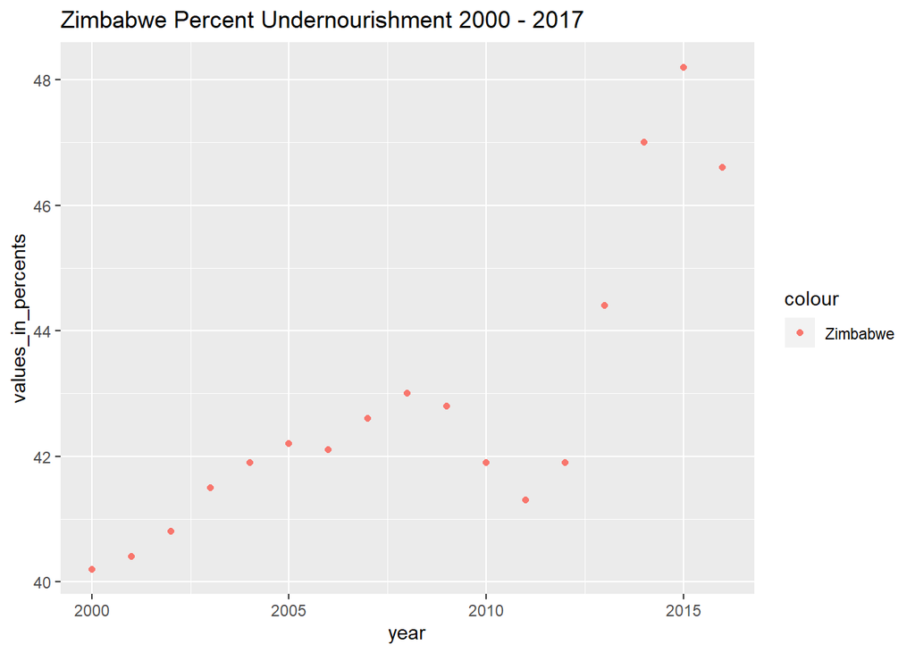

This shows that 2015 was the peak prevelance of undernourishment in Zimbabwe. It seems to have rapidly risen since 2011 and may be on the decline now.

## Chart 2

This chart attempts to show Zimbabwe’s commodity prices in 2015, the year Zimbabwe had the highest percentage of their population undernourished.

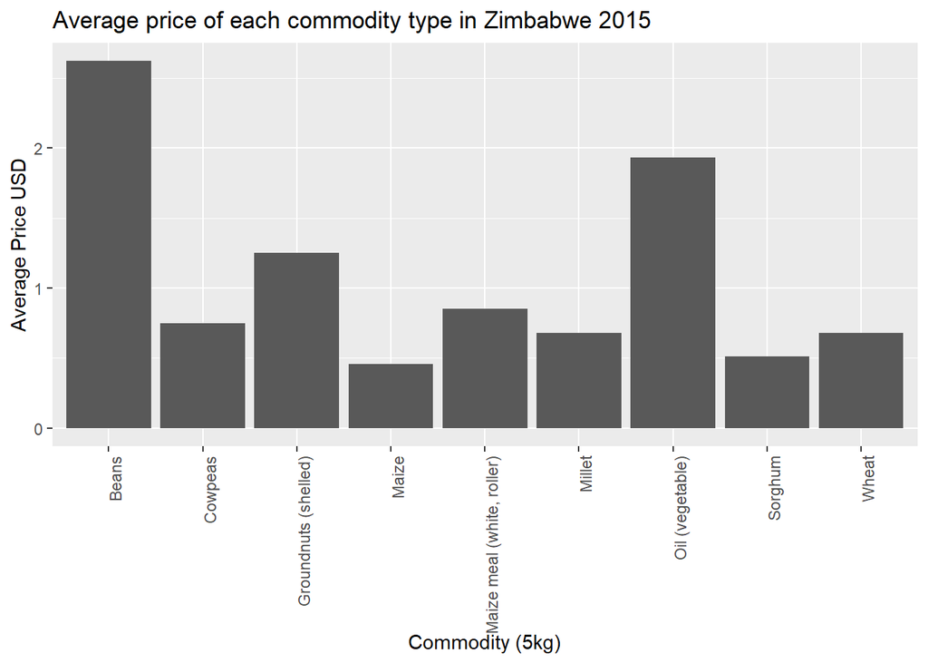

This chart shows that Beans were the most expensive commodity in 2015 with a price close to $3 USD. Maize and other grains in general were much cheaper. As protein is an important nutrient, the high price of beans which contain protein may have contributed to the high percentage of the population that was undernourished in 2015.

## Chart 3

This chart attempts to visualize the global trend of undernourishment between 2000 to 2017.

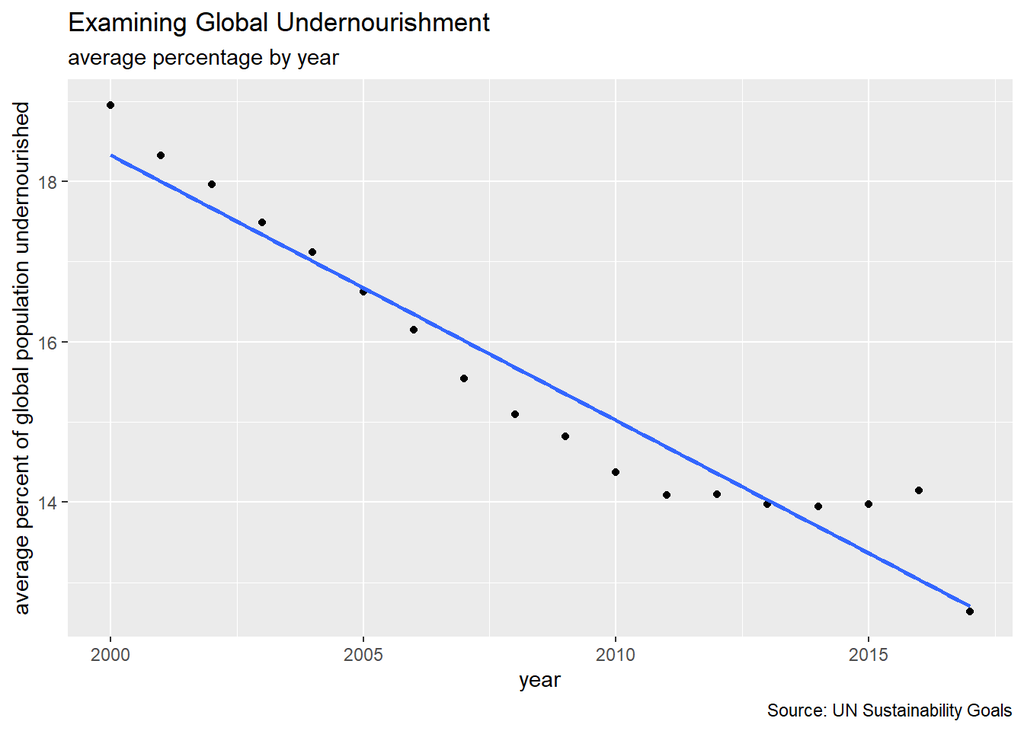

This chart shows a downward trend in global undernourishment, however after 2015 it did appear to be increasing, with a quick downturn towards 2017.